# Reproducible Research: Peer Assessment 1

```r
library(readr)
library(dplyr)
```

```r
library(ggplot2)
library(lattice)
library(knitr)
```

## Loading and preprocessing the data

```r
data <- read_csv("activity.zip", col_names = TRUE)
```

## What is mean total number of steps taken per day?

**1-2. The total number of steps taken per day & a histogram of the total number of steps taken each day:**

```r
total_steps <- data %>% filter(!is.na(steps)) %>% group_by(date) %>% summarize(total_steps_aday = sum(steps))
```

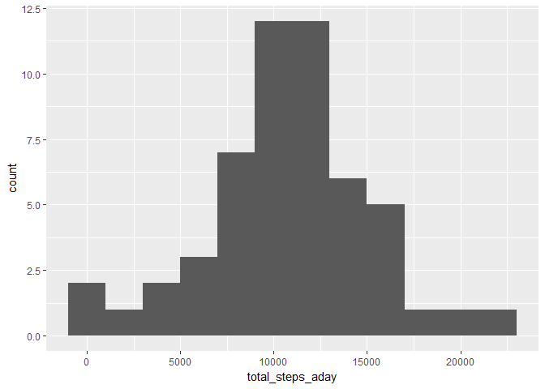

```r
ggplot(total_steps, aes(total_steps_aday)) + geom_histogram(binwidth = 2000)
```

**3. The mean and median of the total number of steps taken per day:**

```r
mean(total_steps$total_steps_aday)
```

```
## [1] 10766.19
```

```r
median(total_steps$total_steps_aday)
```

```
## [1] 10765
```

## What is the average daily activity pattern?

**1. A time series plot (i.e. type = “l”) of the 5-minute interval (x-axis) and the average number of steps taken, averaged across all days (y-axis):**

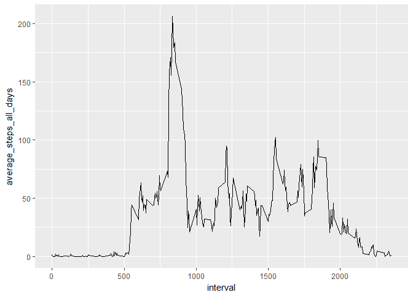

```r
average_steps <- data %>% filter(!is.na(steps)) %>% group_by(interval) %>% summarise(average_steps_all_days = mean(steps))
ggplot(average_steps, aes(x=interval, y=average_steps_all_days)) + geom_line()
```

**2. Which 5-minute interval, on average across all the days in the dataset, contains the maximum number of steps?**

```r
average_steps$interval[which(average_steps$average_steps_all_days == max(average_steps$average_steps_all_days))]
```

```
## [1] 835
```

## Imputing missing values

**1. Calculate and report the total number of missing values in the dataset (i.e. the total number of rows with NAs):**

```r
data$steps %>% is.na() %>% sum()
```

```
## [1] 2304
```

**2-3. Devise a strategy for filling in all of the missing values in the dataset. Create a new dataset that is equal to the original dataset but with the missing data filled in:**

The missing values are filled in with the values that are equal to the median steps for the corresponding interval:

```r
median_steps <- data %>% filter(!is.na(steps)) %>% group_by(interval) %>% summarise(median_steps_alldays = median(steps))

data_new <- data

for (i in 1:nrow(data_new)) {

    if (is.na(data_new$steps[i])) {

        data_new$steps[i] <- median_steps$median_steps_alldays[which(median_steps$interval == data_new$interval[i])]

    }

}
```

**4. Make a histogram of the total number of steps taken each day:**

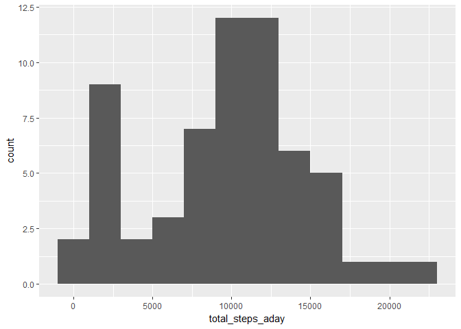

```r
total_steps_new <- data_new %>% group_by(date) %>% summarize(total_steps_aday = sum(steps))
ggplot(total_steps_new, aes(total_steps_aday)) + geom_histogram(binwidth = 2000)
```

**Calculate and report the mean and median total number of steps taken per day.**

```r
mean(total_steps_new$total_steps_aday)
```

```
## [1] 9503.869
```

```r
median(total_steps_new$total_steps_aday)
```

```
## [1] 10395
```

**What is the impact of imputing missing data on the estimates of the total daily number of steps?**

The difference between the means before and after the imputing the missing data:

```r
mean(total_steps$total_steps_aday) - mean(total_steps_new$total_steps_aday)
```

```
## [1] 1262.32
```

The difference between the meadians before and after the imputing the missing data:

```r
median(total_steps$total_steps_aday) - median(total_steps_new$total_steps_aday)
```

```
## [1] 370
```

## Are there differences in activity patterns between weekdays and weekends?

**Create a new factor variable in the dataset with two levels - “weekday” and “weekend” indicating whether a given date is a weekday or weekend day:**

```r
data_new <- data_new %>% mutate(weekday = weekdays(date))
data_new <- data_new %>% mutate(weekday = if_else(weekday == "Saturday" | weekday == "Sunday", "Weekend", "Weekday"))
data_new <- data_new %>% mutate(weekday = as.factor(weekday))
```

**Make a panel plot containing a time series plot (i.e. type = “l”) of the 5-minute interval (x-axis) and the average number of steps taken, averaged across all weekday days or weekend days (y-axis):**

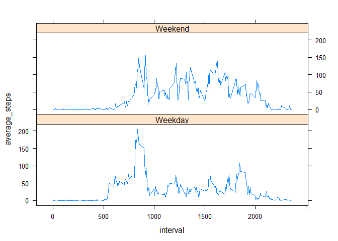

```r
average_steps_new <- data_new %>% group_by(weekday, interval) %>% summarise(average_steps = mean(steps))

#ggplot(average_steps_new, aes(x=interval, y=average_steps)) + geom_line() + facet_grid(weekday ~ .)
xyplot(average_steps ~ interval|weekday, data = average_steps_new, type = "l", layout = c(1,2))
```